# Data clean/ EDA

2023-02-18

# Thesis Preliminary Analyses

## Prepare Data For Analysis

#### Import & Select data

```r
### Import dataset
setwd("~/Desktop/Adams_lab/SPSS_stuff")
NHRVS_2019 <- read_sav("~/Desktop/Adams_lab/SPSS_stuff/NHRVS_2019_2020_FINAL_weighted.sav")

### Select and rename Variables
thesis_NHRVS <- dplyr::select(NHRVS_2019,
    #Background Variables __________
      caseid,Age,Male_Gender,White_Race,SomeCollege_or_Higher,
      Married_Partnered,Income_60k_plus,YN_work,
      PCS_FINAL,MCS_FINAL,Weight_kg,BMI,
    #Military variables__________
      Combat_Veteran,Years_in_Military,Branch_5cat,Enlistment_status_3cat,
      MilitaryRank_3cat,
    #Mental Health Variables___________
      TOTAL_TRAUMAS,LT_PCL_33,LT_MDD_Sx_only,LT_Suicide_4cat,Suicide_Attempt_LT,
      LT_Suicide_Plan,LT_AUD,LT_NicotineDep,LT_DUD,tot_MHC,Any_MHC,
    #Physical health Variables_________
      ANY_ADL_DISABILITY,ANY_IADL_DISABILITY,Any_Disability,tot_phc,Any_PHC,Q22A_1,Q22A_2,
      Q22A_3,Q22A_4,Q22A_5,Q22A_6,Q22A_7,Q22A_8,Q22A_9,Q22A_10,Q22A_11,Q22B_1,
      Q22B_2,Q22B_3,Q22B_4,Q22B_5,
    #Exercise variables ___________
      godin_mild_winsor,godin_Mod_winsor,godin_Stren_winsor,HCS,HCS_Cats,
      godin_total_ac,god3cat,god2cat,GODIN_outliers)

#Rename variabes
thesis_NHRVS <- rename(thesis_NHRVS,
      MET_total = godin_total_ac,
      God_mild = godin_mild_winsor,
      God_mod = godin_Mod_winsor,
      God_stren = godin_Stren_winsor,
      College = SomeCollege_or_Higher,
      MCS = MCS_FINAL,
      PCS = PCS_FINAL,
      Arthritis = Q22A_1,
      Athsma =  Q22A_2,
      Cancer = Q22A_3,
      Chron_pain = Q22A_4,
      Liv_dis = Q22A_5,
      Diabetes = Q22A_6,
      Hrt_dis = Q22A_7,
      Hrt_atk = Q22A_8,
      High_chol = Q22A_9,
      High_bld_press = Q22A_10,
      Kid_dis = Q22A_11,
      Migrane = Q22B_1,
      MS = Q22B_2,
      Osteoporosis = Q22B_3,
      Rhum_arth = Q22B_4,
      Stroke = Q22B_5,
      LT_MDD = LT_MDD_Sx_only,
      LT_PTSD = LT_PCL_33
)



#view(thesis_NHRVS)
thesis_NHRVS
```

```
## # A tibble: 4,069 × 58
##    caseid   Age Male_Gender White_…¹ College Marri…² Incom…³ YN_work   PCS   MCS
##     <dbl> <dbl> <dbl+lbl>      <dbl>   <dbl>   <dbl>   <dbl>   <dbl> <dbl> <dbl>
##  1   1416    48 1 [Male]           0       1       1       1       1  42.0  45.2
##  2   2525    72 1 [Male]           1       1       1       0       2  46.1  48.4
##  3   3050    67 1 [Male]           1       0       1       1       2  37.9  43.4
##  4   2491    66 1 [Male]           1       1       1       0       2  54.3  54.6
##  5   1580    48 1 [Male]           1       1       1       1       1  53.1  53.1
##  6   3946    49 1 [Male]           0       1       0       1       1  55.4  57.2
##  7   3441    63 1 [Male]           0       1       0       0       2  37.9  57.0
##  8   3592    58 1 [Male]           1       0       1       0       2  26.0  28.0
##  9   2182    64 0 [Female]         1       1       1       0       1  39.1  19.8
## 10   1311    54 1 [Male]           0       0       0       0       2  25.9  21.4
## # … with 4,059 more rows, 48 more variables: Weight_kg <dbl>, BMI <dbl>,
## #   Combat_Veteran <dbl+lbl>, Years_in_Military <dbl+lbl>,
## #   Branch_5cat <dbl+lbl>, Enlistment_status_3cat <dbl+lbl>,
## #   MilitaryRank_3cat <dbl+lbl>, TOTAL_TRAUMAS <dbl>, LT_PTSD <dbl>,
## #   LT_MDD <dbl>, LT_Suicide_4cat <dbl+lbl>, Suicide_Attempt_LT <dbl>,
## #   LT_Suicide_Plan <dbl>, LT_AUD <dbl>, LT_NicotineDep <dbl>, LT_DUD <dbl>,
## #   tot_MHC <dbl>, Any_MHC <dbl>, ANY_ADL_DISABILITY <dbl>, …
```

#### Create New Exercise variables

#### Adjust variables for analysis

```r
# We need exercsie variables that are in MET minutes, not just HCS.
# We also need to create demographic and health variables

thesis_NHRVS<- thesis_NHRVS %>%
  # First Create all of the variables
  mutate(thesis_NHRVS,
    # Exercise variables
         Ex_time = (God_mild + God_mod + God_stren)*15,
            # Tells us how long people exercised for.
         MET_min = MET_total* 15,
         MET_min_outlier = ifelse(MET_min < 2000, MET_min,NA),
            # Total METs per week times the duration of exercise
         Ex_rec = as.factor(ifelse(MET_min >= 500, "Sufficient", "Insufficient")),
            # Meeting activity levels (i.e., sufficient vs insufficient)
         Ex_3cat = as.factor(ifelse(MET_min < 290, 1,
                              ifelse(MET_min < 500 & MET_min >= 290, 2,3))),
            # 3 godin (HCS) categories converted to MET_min
    # Other Variables
         Yr5_Military = as.factor(ifelse(Years_in_Military >= 5, "5+", "<5")),
         Active_PA = as.factor(ifelse(Ex_3cat == 3,1,0)),
         Moderate_PA = as.factor(ifelse(Ex_3cat == 2,1,0)),
         Insuf_PA = as.factor(ifelse(Ex_3cat == 2,1,0))
         ) %>%
  #Now lets make all of our IV's factors
    mutate(thesis_NHRVS,
      #Physical health variables
           Any_Disability = as.factor(Any_Disability),
           Arthritis = as.factor(Arthritis),
           Athsma = as.factor(Athsma),
           Cancer = as.factor(Cancer),
           Chron_pain = as.factor(Chron_pain),
           Liv_dis = as.factor(Liv_dis),
           Diabetes = as.factor(Diabetes),
           Hrt_dis = as.factor(Hrt_dis),
           Hrt_atk = as.factor(Hrt_atk),
           High_chol = as.factor(High_chol),
           High_bld_press = as.factor(High_bld_press),
           Kid_dis = as.factor(Kid_dis),
           Migrane = as.factor(Migrane),
           MS = as.factor(MS),
           Osteoporosis = as.factor(Osteoporosis),
           Rhum_arth = as.factor(Rhum_arth),
           Stroke = as.factor(Stroke),
      #Mental health variables
           LT_Suicide_4cat = as.factor(LT_Suicide_4cat),
                LT_Suicidal = recode(LT_Suicide_4cat,
                         "0" = "0",
                         "1" = "0",
                         "2" = "1",
                         "3" = "1"
                             ),
          LT_MDD = as.factor(LT_MDD),
          LT_PTSD = as.factor(LT_PTSD),
          LT_AUD = as.factor(LT_AUD),
          LT_DUD = as.factor(LT_DUD),
          LT_NicotineDep = as.factor(LT_NicotineDep)
    )

  # Next Lets recode all of the factors
thesis_NHRVS <- mutate(thesis_NHRVS,
    Ex_3cat = as.factor(Ex_3cat),
    Ex_3cat = recode(Ex_3cat,
                         "1" = "Insufficient",
                         "2" = "Moderate",
                         "3" = "Active"
                     ),
    Male_Gender = as.factor(Male_Gender),
        Male_Gender = recode(Male_Gender,
                         "0" = "Female",
                         "1" = "Male"),
    Married_Partnered = as.factor(Married_Partnered),
        Married_Partnered = recode(Married_Partnered,
                         "0" = "Married_Partnered",
                         "1" = "Single"),
    White_Race = as.factor(White_Race),
        White_Race = recode(White_Race,
                         "0" = "Not_White",
                         "1" = "White"),
    College = as.factor(College),
        College = recode(College,
                         "0" = "No_Colege",
                         "1" = "Some_Colege"),
    Income_60k_plus = as.factor(Income_60k_plus),
        Income_60k_plus = recode(Income_60k_plus,
                         "0" = "Under_60k",
                         "1" = "OVer_60k"),
    YN_work = as.factor(YN_work),
        YN_work = recode(YN_work,
                         "1" = "No_Work",
                         "2" = "Working"),
    Combat_Veteran = as.factor(Combat_Veteran),
      Combat_Veteran = recode(Combat_Veteran,
                         "0" = "No_Combat",
                         "1" = "Combat"),
    Any_MHC = as.factor(Any_MHC),
        Any_MHC = recode(Any_MHC,
                         "0" = "No_con",
                         "1" = "MHC"),
    Any_PHC = as.factor(Any_PHC),
        Any_PHC = recode(Any_PHC,
                         "0" = "No_con",
                         "1" = "PHC"))
thesis_NHRVS$god2cat = as.factor(thesis_NHRVS$god2cat)

thesis_NHRVS <- thesis_NHRVS %>%
  filter(!is.na(Ex_rec)) %>%
  filter(!is.na(MCS)) %>%
  filter(!is.na(PCS)) %>%
  filter(!is.na(BMI))

#View(thesis_NHRVS)
thesis_NHRVS
```

```
## # A tibble: 3,909 × 68
##    caseid   Age Male_Gender White_…¹ College Marri…² Incom…³ YN_work   PCS   MCS
##     <dbl> <dbl> <fct>       <fct>    <fct>   <fct>   <fct>   <fct>   <dbl> <dbl>
##  1   3592    58 Male        White    No_Col… Single  Under_… Working  26.0  28.0
##  2   2182    64 Female      White    Some_C… Single  Under_… No_Work  39.1  19.8
##  3   1311    54 Male        Not_Whi… No_Col… Marrie… Under_… Working  25.9  21.4
##  4   2054    56 Male        White    Some_C… Marrie… Under_… Working  52.0  34.9
##  5   1061    58 Male        Not_Whi… Some_C… Single  Under_… No_Work  53.0  47.4
##  6    138    88 Male        White    Some_C… Single  Under_… Working  20.2  19.8
##  7    825    55 Male        Not_Whi… Some_C… Single  Under_… No_Work  29.9  53.8
##  8   1971    36 Female      Not_Whi… Some_C… Single  Under_… Working  26.1  23.7
##  9   1199    69 Male        White    Some_C… Single  Under_… No_Work  50.9  35.9
## 10   3994    64 Male        White    Some_C… Marrie… OVer_6… No_Work  51.4  39.5
## # … with 3,899 more rows, 58 more variables: Weight_kg <dbl>, BMI <dbl>,
## #   Combat_Veteran <fct>, Years_in_Military <dbl+lbl>, Branch_5cat <dbl+lbl>,
## #   Enlistment_status_3cat <dbl+lbl>, MilitaryRank_3cat <dbl+lbl>,
## #   TOTAL_TRAUMAS <dbl>, LT_PTSD <fct>, LT_MDD <fct>, LT_Suicide_4cat <fct>,
## #   Suicide_Attempt_LT <dbl>, LT_Suicide_Plan <dbl>, LT_AUD <fct>,
## #   LT_NicotineDep <fct>, LT_DUD <fct>, tot_MHC <dbl>, Any_MHC <fct>,
## #   ANY_ADL_DISABILITY <dbl>, ANY_IADL_DISABILITY <dbl>, …
```

means of variables

```r
mean(thesis_NHRVS$MET_min)
```

```
## [1] 517.9547
```

```r
sd(thesis_NHRVS$MET_min)
```

```
## [1] 544.5355
```

```r
mean(thesis_NHRVS$tot_MHC)
```

```
## [1] 1.052187
```

```r
sd(thesis_NHRVS$tot_MHC)
```

```
## [1] 1.237564
```

```r
range(thesis_NHRVS$tot_MHC)
```

```
## [1] 0 6
```

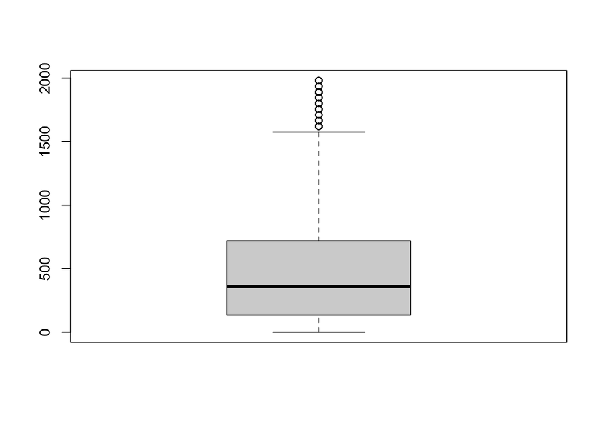

```r
boxplot(thesis_NHRVS$MET_min_outlier)
```

This code does a few things:

1. Creates new variables.
2. Changes the factored variables from 0 & 1 to their respective factored labels. if you don’t change them to factors, the exploratory data analysis will take them quanitative variables rather than categorical variables. I also like changing them factors because it makes it easier to interpret.
3. Changes the IVs that were not factors into factored variables.

## Exploratory Data Analysis (EDA)

#### Associations With Exercsie

```r
library(tableone)
EX_Vars <- c("Age", "Male_Gender", "White_Race", "College",
                 "Married_Partnered", "Income_60k_plus", "YN_work", "PCS",
                 "MCS", "Weight_kg", "BMI", "Combat_Veteran",
                 "Yr5_Military", "TOTAL_TRAUMAS", "tot_phc",
                 "tot_MHC")

EX_catVars     <- c("Male_Gender", "White_Race", "College",
                 "Married_Partnered", "Income_60k_plus", "YN_work", "Combat_Veteran",
                 "Yr5_Military","Ex_3cat")
Exercise_EDA <- CreateTableOne(vars = EX_Vars, strata = "Ex_3cat", data = thesis_NHRVS,
               factorVars = EX_catVars)


full_sample<- CreateTableOne(vars = EX_Vars, data = thesis_NHRVS,
               factorVars = EX_catVars)
full_sample <- print(full_sample, formatOptions = list(big.mark = ","))
```

```
##
##                                  Overall
##   n                              3,909
##   Age (mean (SD))                66.66 (13.08)
##   Male_Gender = Male (%)          3436 (87.9)
##   White_Race = White (%)          3199 (81.8)
##   College = Some_Colege (%)       3382 (86.5)
##   Married_Partnered = Single (%)  2774 (71.0)
##   Income_60k_plus = OVer_60k (%)  2285 (58.5)
##   YN_work = Working (%)           2359 (60.3)
##   PCS (mean (SD))                46.83 (9.48)
##   MCS (mean (SD))                53.27 (7.61)
##   Weight_kg (mean (SD))          89.88 (18.91)
##   BMI (mean (SD))                28.94 (5.48)
##   Combat_Veteran = Combat (%)     1292 (33.1)
##   Yr5_Military = 5+ (%)           1419 (36.3)
##   TOTAL_TRAUMAS (mean (SD))       9.08 (8.30)
##   tot_phc (mean (SD))             2.76 (1.97)
##   tot_MHC (mean (SD))             1.05 (1.24)
```

```r
test_tab <- print(Exercise_EDA, formatOptions = list(big.mark = ","))
```

```
##                                 Stratified by Ex_3cat
##                                  Insufficient  Moderate      Active
##   n                              1,589           779         1,541
##   Age (mean (SD))                67.60 (12.65) 67.56 (12.64) 65.24 (13.60)
##   Male_Gender = Male (%)          1377 (86.7)    693 (89.0)   1366 (88.6)
##   White_Race = White (%)          1304 (82.1)    639 (82.0)   1256 (81.5)
##   College = Some_Colege (%)       1316 (82.8)    673 (86.4)   1393 (90.4)
##   Married_Partnered = Single (%)  1096 (69.0)    555 (71.2)   1123 (72.9)
##   Income_60k_plus = OVer_60k (%)   849 (53.4)    471 (60.5)    965 (62.6)
##   YN_work = Working (%)           1033 (65.0)    467 (59.9)    859 (55.7)
##   PCS (mean (SD))                43.70 (10.47) 47.92 (8.51)  49.50 (7.80)
##   MCS (mean (SD))                52.44 (8.35)  53.66 (6.81)  53.93 (7.10)
##   Weight_kg (mean (SD))          92.52 (20.29) 89.83 (17.78) 87.19 (17.56)
##   BMI (mean (SD))                29.91 (6.01)  28.86 (5.22)  27.97 (4.81)
##   Combat_Veteran = Combat (%)      499 (31.5)    253 (32.5)    540 (35.1)
##   Yr5_Military = 5+ (%)            553 (34.8)    278 (35.7)    588 (38.2)
##   TOTAL_TRAUMAS (mean (SD))       8.38 (7.85)   9.49 (8.48)   9.59 (8.60)
##   tot_phc (mean (SD))             3.08 (2.10)   2.71 (1.80)   2.46 (1.86)
##   tot_MHC (mean (SD))             1.16 (1.30)   0.97 (1.18)   0.99 (1.20)
##                                 Stratified by Ex_3cat
##                                  p      test
##   n
##   Age (mean (SD))                <0.001
##   Male_Gender = Male (%)          0.140
##   White_Race = White (%)          0.910
##   College = Some_Colege (%)      <0.001
##   Married_Partnered = Single (%)  0.055
##   Income_60k_plus = OVer_60k (%) <0.001
##   YN_work = Working (%)          <0.001
##   PCS (mean (SD))                <0.001
##   MCS (mean (SD))                <0.001
##   Weight_kg (mean (SD))          <0.001
##   BMI (mean (SD))                <0.001
##   Combat_Veteran = Combat (%)     0.085
##   Yr5_Military = 5+ (%)           0.138
##   TOTAL_TRAUMAS (mean (SD))      <0.001
##   tot_phc (mean (SD))            <0.001
##   tot_MHC (mean (SD))            <0.001
```

```r
#Demo_tab <-
  test_tab[,1:4]
```

```
##                                 Stratified by Ex_3cat
##                                  Insufficient    Moderate
##   n                              "1,589"         "  779"
##   Age (mean (SD))                "67.60 (12.65)" "67.56 (12.64)"
##   Male_Gender = Male (%)         " 1377 (86.7) " "  693 (89.0) "
##   White_Race = White (%)         " 1304 (82.1) " "  639 (82.0) "
##   College = Some_Colege (%)      " 1316 (82.8) " "  673 (86.4) "
##   Married_Partnered = Single (%) " 1096 (69.0) " "  555 (71.2) "
##   Income_60k_plus = OVer_60k (%) "  849 (53.4) " "  471 (60.5) "
##   YN_work = Working (%)          " 1033 (65.0) " "  467 (59.9) "
##   PCS (mean (SD))                "43.70 (10.47)" "47.92 (8.51)"
##   MCS (mean (SD))                "52.44 (8.35)"  "53.66 (6.81)"
##   Weight_kg (mean (SD))          "92.52 (20.29)" "89.83 (17.78)"
##   BMI (mean (SD))                "29.91 (6.01)"  "28.86 (5.22)"
##   Combat_Veteran = Combat (%)    "  499 (31.5) " "  253 (32.5) "
##   Yr5_Military = 5+ (%)          "  553 (34.8) " "  278 (35.7) "
##   TOTAL_TRAUMAS (mean (SD))      " 8.38 (7.85)"  " 9.49 (8.48)"
##   tot_phc (mean (SD))            " 3.08 (2.10)"  " 2.71 (1.80)"
##   tot_MHC (mean (SD))            " 1.16 (1.30)"  " 0.97 (1.18)"
##                                 Stratified by Ex_3cat
##                                  Active          p
##   n                              "1,541"         ""
##   Age (mean (SD))                "65.24 (13.60)" "<0.001"
##   Male_Gender = Male (%)         " 1366 (88.6) " " 0.140"
##   White_Race = White (%)         " 1256 (81.5) " " 0.910"
##   College = Some_Colege (%)      " 1393 (90.4) " "<0.001"
##   Married_Partnered = Single (%) " 1123 (72.9) " " 0.055"
##   Income_60k_plus = OVer_60k (%) "  965 (62.6) " "<0.001"
##   YN_work = Working (%)          "  859 (55.7) " "<0.001"
##   PCS (mean (SD))                "49.50 (7.80)"  "<0.001"
##   MCS (mean (SD))                "53.93 (7.10)"  "<0.001"
##   Weight_kg (mean (SD))          "87.19 (17.56)" "<0.001"
##   BMI (mean (SD))                "27.97 (4.81)"  "<0.001"
##   Combat_Veteran = Combat (%)    "  540 (35.1) " " 0.085"
##   Yr5_Military = 5+ (%)          "  588 (38.2) " " 0.138"
##   TOTAL_TRAUMAS (mean (SD))      " 9.59 (8.60)"  "<0.001"
##   tot_phc (mean (SD))            " 2.46 (1.86)"  "<0.001"
##   tot_MHC (mean (SD))            " 0.99 (1.20)"  "<0.001"
```

```r
#View(Demo_tab)
Demo_tab <- cbind(full_sample, test_tab[,1:4])
Demo_tab
```

```
##                                Overall         Insufficient    Moderate
## n                              "3,909"         "1,589"         "  779"
## Age (mean (SD))                "66.66 (13.08)" "67.60 (12.65)" "67.56 (12.64)"
## Male_Gender = Male (%)         " 3436 (87.9) " " 1377 (86.7) " "  693 (89.0) "
## White_Race = White (%)         " 3199 (81.8) " " 1304 (82.1) " "  639 (82.0) "
## College = Some_Colege (%)      " 3382 (86.5) " " 1316 (82.8) " "  673 (86.4) "
## Married_Partnered = Single (%) " 2774 (71.0) " " 1096 (69.0) " "  555 (71.2) "
## Income_60k_plus = OVer_60k (%) " 2285 (58.5) " "  849 (53.4) " "  471 (60.5) "
## YN_work = Working (%)          " 2359 (60.3) " " 1033 (65.0) " "  467 (59.9) "
## PCS (mean (SD))                "46.83 (9.48)"  "43.70 (10.47)" "47.92 (8.51)"
## MCS (mean (SD))                "53.27 (7.61)"  "52.44 (8.35)"  "53.66 (6.81)"
## Weight_kg (mean (SD))          "89.88 (18.91)" "92.52 (20.29)" "89.83 (17.78)"
## BMI (mean (SD))                "28.94 (5.48)"  "29.91 (6.01)"  "28.86 (5.22)"
## Combat_Veteran = Combat (%)    " 1292 (33.1) " "  499 (31.5) " "  253 (32.5) "
## Yr5_Military = 5+ (%)          " 1419 (36.3) " "  553 (34.8) " "  278 (35.7) "
## TOTAL_TRAUMAS (mean (SD))      " 9.08 (8.30)"  " 8.38 (7.85)"  " 9.49 (8.48)"
## tot_phc (mean (SD))            " 2.76 (1.97)"  " 3.08 (2.10)"  " 2.71 (1.80)"
## tot_MHC (mean (SD))            " 1.05 (1.24)"  " 1.16 (1.30)"  " 0.97 (1.18)"
##                                Active          p
## n                              "1,541"         ""
## Age (mean (SD))                "65.24 (13.60)" "<0.001"
## Male_Gender = Male (%)         " 1366 (88.6) " " 0.140"
## White_Race = White (%)         " 1256 (81.5) " " 0.910"
## College = Some_Colege (%)      " 1393 (90.4) " "<0.001"
## Married_Partnered = Single (%) " 1123 (72.9) " " 0.055"
## Income_60k_plus = OVer_60k (%) "  965 (62.6) " "<0.001"
## YN_work = Working (%)          "  859 (55.7) " "<0.001"
## PCS (mean (SD))                "49.50 (7.80)"  "<0.001"
## MCS (mean (SD))                "53.93 (7.10)"  "<0.001"
## Weight_kg (mean (SD))          "87.19 (17.56)" "<0.001"
## BMI (mean (SD))                "27.97 (4.81)"  "<0.001"
## Combat_Veteran = Combat (%)    "  540 (35.1) " " 0.085"
## Yr5_Military = 5+ (%)          "  588 (38.2) " " 0.138"
## TOTAL_TRAUMAS (mean (SD))      " 9.59 (8.60)"  "<0.001"
## tot_phc (mean (SD))            " 2.46 (1.86)"  "<0.001"
## tot_MHC (mean (SD))            " 0.99 (1.20)"  "<0.001"
```

#### Associations With Health Conditions

```r
Demo_tab<- as.data.frame(Demo_tab)
write_csv(Demo_tab, "~/Desktop/Coding/data/Demo_tab_basic.csv")
```

I used the PTSD*Godin demographic table as a reference for designing this table.

These variables should be used for the regressions/ancovas - Age,Some_college_or_higher, Income_60K_plus, YN_work, PCS_final or MCS_final, combat veteran (maybe), weight (maybe?)

## Export to SPSS

```r
#I'm exporting my dataset to SPSS beucase I want to make sure I'm doing the analyses on the same set of data, sense I changed some variabels I don't want to compare this to the old datset.
write_sav(thesis_NHRVS, "~/Desktop/Coding/data/thesis_NHRVS.sav")
write_csv(thesis_NHRVS, "~/Desktop/Coding/data/thesis_NHRVS.csv")
```

## Test of difference

This next section is extracting the F test score and chi square test (X) values for the analysis above. These values will be used in the final demogrpahics table

#### Physical activity levels

```r
library(gmodels)
#### Create test of difference values and put them into a table

#Age
Age_test_act <- aov(Age~ Ex_3cat, data = thesis_NHRVS)
test_act_vars = c('Age')
Activity_val = c(summary(Age_test_act)[[1]]$`F value`[[1]])
Activity_p = c(summary(Age_test_act)[[1]]$`Pr(>F)`[[1]])
Activity_p
```

```
## [1] 3.012644e-07
```

```r
#Gender
Male_test_act<- xtabs(~Ex_3cat+Male_Gender, data=thesis_NHRVS)
test_act_vars <- append(test_act_vars,'Male')
Activity_val <- append(Activity_val,summary(Male_test_act)[[3]])
Activity_p <- append(Activity_p,summary(Male_test_act)[[6]])

Activity_val
```

```
## [1] 15.07315  3.92819
```

```r
Activity_p
```

```
## [1] 3.012644e-07 1.402828e-01
```

```r
#White
White_test_act<- xtabs(~Ex_3cat+White_Race, data=thesis_NHRVS)
test_act_vars <- append(test_act_vars,'White')
Activity_val <- append(Activity_val,summary(White_test_act)[[3]])
Activity_p <- append(Activity_p,summary(White_test_act)[[6]])

#some College
College_test_act<- xtabs(~Ex_3cat+College, data=thesis_NHRVS)
test_act_vars <- append(test_act_vars,'College')
Activity_val <- append(Activity_val,summary(College_test_act)[[3]])
Activity_p <- append(Activity_p,summary(College_test_act)[[6]])

#Married_Partnered
Married_Partnered_test_act<- xtabs(~Ex_3cat+Married_Partnered, data=thesis_NHRVS)
test_act_vars <- append(test_act_vars,'Married_Partnered')
Activity_val <- append(Activity_val,summary(Married_Partnered_test_act)[[3]])
Activity_p <- append(Activity_p,summary(Married_Partnered_test_act)[[6]])

#Income_60k_plus
Income_60k_plus_test_act<- xtabs(~Ex_3cat+Income_60k_plus, data=thesis_NHRVS)
test_act_vars <- append(test_act_vars,'Income_60k_plus')
Activity_val <- append(Activity_val,summary(Income_60k_plus_test_act)[[3]])
Activity_p <- append(Activity_p,summary(Income_60k_plus_test_act)[[6]])

#YN_work
YN_work_test_act<- xtabs(~Ex_3cat+YN_work, data=thesis_NHRVS)
test_act_vars <- append(test_act_vars,'YN_work')
Activity_val <- append(Activity_val,summary(YN_work_test_act)[[3]])
Activity_p <- append(Activity_p,summary(YN_work_test_act)[[6]])

#PCS
PCS_test_act <- aov(PCS~ Ex_3cat, data = thesis_NHRVS)
test_act_vars <- append(test_act_vars,'PCS')
Activity_val <- append(Activity_val,summary(PCS_test_act)[[1]]$`F value`[[1]])
Activity_p <- append(Activity_p,summary(PCS_test_act)[[1]]$`Pr(>F)`[[1]])

#MCS
MCS_test_act <- aov(MCS~ Ex_3cat, data = thesis_NHRVS)
test_act_vars <- append(test_act_vars,'MCS')
Activity_val <- append(Activity_val,summary(MCS_test_act)[[1]]$`F value`[[1]])
Activity_p <- append(Activity_p,summary(MCS_test_act)[[1]]$`Pr(>F)`[[1]])

#BMI
BMI_test_act <- aov(BMI~ Ex_3cat, data = thesis_NHRVS)
test_act_vars <- append(test_act_vars,'BMI')
Activity_val <- append(Activity_val,summary(BMI_test_act)[[1]]$`F value`[[1]])
Activity_p <- append(Activity_p,summary(BMI_test_act)[[1]]$`Pr(>F)`[[1]])

#Combat_Veteran
Combat_Veteran_test_act<- xtabs(~Ex_3cat+Combat_Veteran, data=thesis_NHRVS)
test_act_vars <- append(test_act_vars,'Combat Veteran')
Activity_val <- append(Activity_val,summary(Combat_Veteran_test_act)[[3]])
Activity_p <- append(Activity_p,summary(Combat_Veteran_test_act)[[6]])

#Yr5_Military
Yr5_Military_test_act<- xtabs(~Ex_3cat+Yr5_Military, data=thesis_NHRVS)
test_act_vars <- append(test_act_vars,'5+ Years in Military')
Activity_val <- append(Activity_val,summary(Yr5_Military_test_act)[[3]])
Activity_p <- append(Activity_p,summary(Yr5_Military_test_act)[[6]])

#TOTAL TRAUMAS
TOTAL_TRAUMAS_test_act <- aov(TOTAL_TRAUMAS~ Ex_3cat, data = thesis_NHRVS)
test_act_vars <- append(test_act_vars,'TOTAL TRAUMAS')
Activity_val <- append(Activity_val,summary(TOTAL_TRAUMAS_test_act)[[1]]$`F value`[[1]])
Activity_p <- append(Activity_p,summary(TOTAL_TRAUMAS_test_act)[[1]]$`Pr(>F)`[[1]])

#TOTAL Physical Health Conditions
tot_phc_test_act <- aov(tot_phc~ Ex_3cat, data = thesis_NHRVS)
test_act_vars <- append(test_act_vars,'Total_PHC')
Activity_val <- append(Activity_val,summary(tot_phc_test_act)[[1]]$`F value`[[1]])
Activity_p <- append(Activity_p,summary(tot_phc_test_act)[[1]]$`Pr(>F)`[[1]])

#TOTAL Physical Health Conditions
tot_MHC_test_act <- aov(tot_MHC~ Ex_3cat, data = thesis_NHRVS)
test_act_vars <- append(test_act_vars,'Total MHC')
Activity_val <- append(Activity_val,summary(tot_MHC_test_act)[[1]]$`F value`[[1]])
Activity_p <- append(Activity_p,summary(tot_MHC_test_act)[[1]]$`Pr(>F)`[[1]])


val_df <- data.frame(test_act_vars,Activity_val)
val_df <- cbind(val_df,Activity_p)
val_df
```

```
##           test_act_vars Activity_val   Activity_p
## 1                   Age   15.0731467 3.012644e-07
## 2                  Male    3.9281902 1.402828e-01
## 3                 White    0.1882617 9.101637e-01
## 4               College   38.5132810 4.334583e-09
## 5     Married_Partnered    5.8137166 5.464715e-02
## 6       Income_60k_plus   28.8315163 5.486758e-07
## 7               YN_work   28.1370773 7.764461e-07
## 8                   PCS  165.3177639 1.204611e-69
## 9                   MCS   16.4058588 8.031295e-08
## 10                  BMI   50.2147846 2.935221e-22
## 11       Combat Veteran    4.9248509 8.522798e-02
## 12 5+ Years in Military    3.9674570 1.375554e-01
## 13        TOTAL TRAUMAS    9.5705396 7.140461e-05
## 14            Total_PHC   40.9423700 2.527956e-18
## 15            Total MHC    9.5071192 7.605499e-05
```

#### Physical health Conditions

```r
#### Create test of difference values and put them into a table
#Age
# Age_test_PHC <- aov(Age~ Any_PHC, data = thesis_NHRVS)
# PHC_val = c(summary(Age_test_PHC)[[1]]$`F value`[[1]])
# PHC_p = c(summary(Age_test_PHC)[[1]]$`Pr(>F)`[[1]])
PHC_val <- c(t.test(thesis_NHRVS$Age~thesis_NHRVS$Any_PHC)[[1]])
PHC_p <- c(t.test(thesis_NHRVS$Age~thesis_NHRVS$Any_PHC)[[3]])

#Gender
Male_test_PHC<- xtabs(~Any_PHC+Male_Gender, data=thesis_NHRVS)
summary(Male_test_PHC)
```

```
## Call: xtabs(formula = ~Any_PHC + Male_Gender, data = thesis_NHRVS)
## Number of cases in table: 3909
## Number of factors: 2
## Test for independence of all factors:
##  Chisq = 17.878, df = 1, p-value = 2.356e-05
```

```r
PHC_val <- append(PHC_val,Male_test_PHC[[3]])
PHC_p <- append(PHC_p,summary(Male_test_PHC)[[6]])

#White
White_test_PHC<- xtabs(~Any_PHC+White_Race, data=thesis_NHRVS)
PHC_val <- append(PHC_val,summary(White_test_PHC)[[3]])
PHC_p <- append(PHC_p,summary(White_test_PHC)[[6]])

#some College
College_test_PHC<- xtabs(~Any_PHC+College, data=thesis_NHRVS)
PHC_val <- append(PHC_val,summary(College_test_PHC)[[3]])
PHC_p <- append(PHC_p,summary(College_test_PHC)[[6]])

#Married_Partnered
Married_Partnered_test_PHC<- xtabs(~Any_PHC+Married_Partnered, data=thesis_NHRVS)
PHC_val <- append(PHC_val,summary(Married_Partnered_test_PHC)[[3]])
PHC_p <- append(PHC_p,summary(Married_Partnered_test_PHC)[[6]])

#Income_60k_plus
Income_60k_plus_test_PHC<- xtabs(~Any_PHC+Income_60k_plus, data=thesis_NHRVS)
PHC_val <- append(PHC_val,summary(Income_60k_plus_test_PHC)[[3]])
PHC_p <- append(PHC_p,summary(Income_60k_plus_test_PHC)[[6]])

#YN_work
YN_work_test_PHC<- xtabs(~Any_PHC+YN_work, data=thesis_NHRVS)
PHC_val <- append(PHC_val,summary(YN_work_test_PHC)[[3]])
PHC_p <- append(PHC_p,summary(YN_work_test_PHC)[[6]])

#PCS
#PCS_test_PHC <- xtabs(PCS~ Any_PHC, data = thesis_NHRVS)
#PHC_val <- append(PHC_val,summary(PCS_test_PHC)[[1]]$`F value`[[1]])
#PHC_p <- append(PHC_p,summary(PCS_test_PHC)[[1]]$`Pr(>F)`[[1]])
PHC_val <- append(PHC_val, t.test(thesis_NHRVS$PCS~thesis_NHRVS$Any_PHC)[[1]])
PHC_p <- append(PHC_p, t.test(thesis_NHRVS$PCS~thesis_NHRVS$Any_PHC)[[3]])

#MCS
# MCS_test_PHC <- aov(MCS~ Any_PHC, data = thesis_NHRVS)
# PHC_val <- append(PHC_val,summary(MCS_test_PHC)[[1]]$`F value`[[1]])
# PHC_p <- append(PHC_p,summary(MCS_test_PHC)[[1]]$`Pr(>F)`[[1]])
PHC_val <- append(PHC_val, t.test(thesis_NHRVS$MCS~thesis_NHRVS$Any_PHC)[[1]])
PHC_p <- append(PHC_p, t.test(thesis_NHRVS$MCS~thesis_NHRVS$Any_PHC)[[3]])

#BMI
# BMI_test_PHC <- aov(BMI~ Any_PHC, data = thesis_NHRVS)
# PHC_val <- append(PHC_val,summary(BMI_test_PHC)[[1]]$`F value`[[1]])
# PHC_p <- append(PHC_p,summary(BMI_test_PHC)[[1]]$`Pr(>F)`[[1]])
PHC_val <- append(PHC_val, t.test(thesis_NHRVS$BMI~thesis_NHRVS$Any_PHC)[[1]])
PHC_p <- append(PHC_p, t.test(thesis_NHRVS$BMI~thesis_NHRVS$Any_PHC)[[3]])

#Combat_Veteran
Combat_Veteran_test_PHC<- xtabs(~Any_PHC+Combat_Veteran, data=thesis_NHRVS)
PHC_val <- append(PHC_val,summary(Combat_Veteran_test_PHC)[[3]])
PHC_p <- append(PHC_p,summary(Combat_Veteran_test_PHC)[[6]])

#Yr5_Military
Yr5_Military_test_PHC<- xtabs(~Any_PHC+Yr5_Military, data=thesis_NHRVS)
PHC_val <- append(PHC_val,summary(Yr5_Military_test_PHC)[[3]])
PHC_p <- append(PHC_p,summary(Yr5_Military_test_PHC)[[6]])

#TOTAL TRAUMAS
# TOTAL_TRAUMAS_test_PHC <- aov(TOTAL_TRAUMAS~ Any_PHC, data = thesis_NHRVS)
# PHC_val <- append(PHC_val,summary(TOTAL_TRAUMAS_test_PHC)[[1]]$`F value`[[1]])
# PHC_p <- append(PHC_p,summary(TOTAL_TRAUMAS_test_PHC)[[1]]$`Pr(>F)`[[1]])
PHC_val <- append(PHC_val, t.test(thesis_NHRVS$TOTAL_TRAUMAS~thesis_NHRVS$Any_PHC)[[1]])
PHC_p <- append(PHC_p, t.test(thesis_NHRVS$TOTAL_TRAUMAS~thesis_NHRVS$Any_PHC)[[3]])

#TOTAL Physical Health Conditions
# tot_PHC_test_PHC <- aov(tot_PHC~ Any_PHC, data = thesis_NHRVS)
# PHC_val <- append(PHC_val,summary(tot_PHC_test_PHC)[[1]]$`F value`[[1]])
# PHC_p <- append(PHC_p,summary(tot_PHC_test_PHC)[[1]]$`Pr(>F)`[[1]])
PHC_val <- append(PHC_val, t.test(thesis_NHRVS$tot_phc~thesis_NHRVS$Any_PHC)[[1]])
PHC_p <- append(PHC_p, t.test(thesis_NHRVS$tot_phc~thesis_NHRVS$Any_PHC)[[3]])

t.test(thesis_NHRVS$tot_phc~thesis_NHRVS$Any_PHC)
```

```
##
##  Welch Two Sample t-test
##
## data:  thesis_NHRVS$tot_phc by thesis_NHRVS$Any_PHC
## t = -101.82, df = 3451, p-value < 2.2e-16
## alternative hypothesis: true difference in means between group No_con and group PHC is not equal to 0
## 95 percent confidence interval:
##  -3.186504 -3.066103
## sample estimates:
## mean in group No_con    mean in group PHC
##             0.000000             3.126304
```

```r
#TOTAL Mental Health Conditions
# tot_PHC_test_PHC <- aov(tot_PHC~ Any_PHC, data = thesis_NHRVS)
# PHC_val <- append(PHC_val,summary(tot_PHC_test_PHC)[[1]]$`F value`[[1]])
# PHC_p <- append(PHC_p,summary(tot_PHC_test_PHC)[[1]]$`Pr(>F)`[[1]])
PHC_val <- append(PHC_val, t.test(thesis_NHRVS$tot_MHC~thesis_NHRVS$Any_PHC)[[1]])
PHC_p <- append(PHC_p, t.test(thesis_NHRVS$tot_MHC~thesis_NHRVS$Any_PHC)[[3]])


val_df <- cbind(val_df,PHC_val,PHC_p)
val_df
```

```
##           test_act_vars Activity_val   Activity_p       PHC_val        PHC_p
## 1                   Age   15.0731467 3.012644e-07 -1.399911e+01 3.044311e-38
## 2                  Male    3.9281902 1.402828e-01  3.740000e+02 2.355787e-05
## 3                 White    0.1882617 9.101637e-01  2.659370e-01 6.060704e-01
## 4               College   38.5132810 4.334583e-09  4.096134e-02 8.396126e-01
## 5     Married_Partnered    5.8137166 5.464715e-02  5.767039e-03 9.394660e-01
## 6       Income_60k_plus   28.8315163 5.486758e-07  5.332629e+00 2.092979e-02
## 7               YN_work   28.1370773 7.764461e-07  1.340783e+02 5.252376e-31
## 8                   PCS  165.3177639 1.204611e-69  1.998881e+01 2.540874e-72
## 9                   MCS   16.4058588 8.031295e-08  1.112485e+00 2.663829e-01
## 10                  BMI   50.2147846 2.935221e-22 -8.460162e+00 1.880064e-16
## 11       Combat Veteran    4.9248509 8.522798e-02  6.617893e+00 1.009592e-02
## 12 5+ Years in Military    3.9674570 1.375554e-01  7.039625e-01 4.014554e-01
## 13        TOTAL TRAUMAS    9.5705396 7.140461e-05 -6.696000e+00 4.632853e-11
## 14            Total_PHC   40.9423700 2.527956e-18 -1.018195e+02 0.000000e+00
## 15            Total MHC    9.5071192 7.605499e-05 -3.187127e+00 1.512391e-03
```

#### Mental Health Conditions

```r
#### Create test of difference values and put them into a table
#Age
# Age_test_MHC <- aov(Age~ Any_MHC, data = thesis_NHRVS)
# MHC_val = c(summary(Age_test_MHC)[[1]]$`F value`[[1]])
# MHC_p = c(summary(Age_test_MHC)[[1]]$`Pr(>F)`[[1]])
MHC_val <- c(t.test(thesis_NHRVS$Age~thesis_NHRVS$Any_MHC)[[1]])
MHC_p <- c(t.test(thesis_NHRVS$Age~thesis_NHRVS$Any_MHC)[[3]])

#Gender
Male_test_MHC<- xtabs(~Any_MHC+Male_Gender, data=thesis_NHRVS)
summary(Male_test_MHC)
```

```
## Call: xtabs(formula = ~Any_MHC + Male_Gender, data = thesis_NHRVS)
## Number of cases in table: 3909
## Number of factors: 2
## Test for independence of all factors:
##  Chisq = 23.277, df = 1, p-value = 1.402e-06
```

```r
MHC_val <- append(MHC_val,Male_test_MHC[[3]])
MHC_p <- append(MHC_p,summary(Male_test_MHC)[[6]])

#White
White_test_MHC<- xtabs(~Any_MHC+White_Race, data=thesis_NHRVS)
MHC_val <- append(MHC_val,summary(White_test_MHC)[[3]])
MHC_p <- append(MHC_p,summary(White_test_MHC)[[6]])

#some College
College_test_MHC<- xtabs(~Any_MHC+College, data=thesis_NHRVS)
MHC_val <- append(MHC_val,summary(College_test_MHC)[[3]])
MHC_p <- append(MHC_p,summary(College_test_MHC)[[6]])

#Married_Partnered
Married_Partnered_test_MHC<- xtabs(~Any_MHC+Married_Partnered, data=thesis_NHRVS)
MHC_val <- append(MHC_val,summary(Married_Partnered_test_MHC)[[3]])
MHC_p <- append(MHC_p,summary(Married_Partnered_test_MHC)[[6]])

#Income_60k_plus
Income_60k_plus_test_MHC<- xtabs(~Any_MHC+Income_60k_plus, data=thesis_NHRVS)
MHC_val <- append(MHC_val,summary(Income_60k_plus_test_MHC)[[3]])
MHC_p <- append(MHC_p,summary(Income_60k_plus_test_MHC)[[6]])

#YN_work
YN_work_test_MHC<- xtabs(~Any_MHC+YN_work, data=thesis_NHRVS)
MHC_val <- append(MHC_val,summary(YN_work_test_MHC)[[3]])
MHC_p <- append(MHC_p,summary(YN_work_test_MHC)[[6]])

#PCS
#PCS_test_MHC <- xtabs(PCS~ Any_MHC, data = thesis_NHRVS)
#MHC_val <- append(MHC_val,summary(PCS_test_MHC)[[1]]$`F value`[[1]])
#MHC_p <- append(MHC_p,summary(PCS_test_MHC)[[1]]$`Pr(>F)`[[1]])
MHC_val <- append(MHC_val, t.test(thesis_NHRVS$PCS~thesis_NHRVS$Any_MHC)[[1]])
MHC_p <- append(MHC_p, t.test(thesis_NHRVS$PCS~thesis_NHRVS$Any_MHC)[[3]])

#MCS
# MCS_test_MHC <- aov(MCS~ Any_MHC, data = thesis_NHRVS)
# MHC_val <- append(MHC_val,summary(MCS_test_MHC)[[1]]$`F value`[[1]])
# MHC_p <- append(MHC_p,summary(MCS_test_MHC)[[1]]$`Pr(>F)`[[1]])
MHC_val <- append(MHC_val, t.test(thesis_NHRVS$MCS~thesis_NHRVS$Any_MHC)[[1]])
MHC_p <- append(MHC_p, t.test(thesis_NHRVS$MCS~thesis_NHRVS$Any_MHC)[[3]])

#BMI
# BMI_test_MHC <- aov(BMI~ Any_MHC, data = thesis_NHRVS)
# MHC_val <- append(MHC_val,summary(BMI_test_MHC)[[1]]$`F value`[[1]])
# MHC_p <- append(MHC_p,summary(BMI_test_MHC)[[1]]$`Pr(>F)`[[1]])
MHC_val <- append(MHC_val, t.test(thesis_NHRVS$BMI~thesis_NHRVS$Any_MHC)[[1]])
MHC_p <- append(MHC_p, t.test(thesis_NHRVS$BMI~thesis_NHRVS$Any_MHC)[[3]])

#Combat_Veteran
Combat_Veteran_test_MHC<- xtabs(~Any_MHC+Combat_Veteran, data=thesis_NHRVS)
MHC_val <- append(MHC_val,summary(Combat_Veteran_test_MHC)[[3]])
MHC_p <- append(MHC_p,summary(Combat_Veteran_test_MHC)[[6]])

#Yr5_Military
Yr5_Military_test_MHC<- xtabs(~Any_MHC+Yr5_Military, data=thesis_NHRVS)
MHC_val <- append(MHC_val,summary(Yr5_Military_test_MHC)[[3]])
MHC_p <- append(MHC_p,summary(Yr5_Military_test_MHC)[[6]])

#TOTAL TRAUMAS
# TOTAL_TRAUMAS_test_MHC <- aov(TOTAL_TRAUMAS~ Any_MHC, data = thesis_NHRVS)
# MHC_val <- append(MHC_val,summary(TOTAL_TRAUMAS_test_MHC)[[1]]$`F value`[[1]])
# MHC_p <- append(MHC_p,summary(TOTAL_TRAUMAS_test_MHC)[[1]]$`Pr(>F)`[[1]])
MHC_val <- append(MHC_val, t.test(thesis_NHRVS$TOTAL_TRAUMAS~thesis_NHRVS$Any_MHC)[[1]])
MHC_p <- append(MHC_p, t.test(thesis_NHRVS$TOTAL_TRAUMAS~thesis_NHRVS$Any_MHC)[[3]])

#TOTAL Physical Health Conditions
# tot_MHC_test_MHC <- aov(tot_MHC~ Any_MHC, data = thesis_NHRVS)
# MHC_val <- append(MHC_val,summary(tot_MHC_test_MHC)[[1]]$`F value`[[1]])
# MHC_p <- append(MHC_p,summary(tot_MHC_test_MHC)[[1]]$`Pr(>F)`[[1]])
MHC_val <- append(MHC_val, t.test(thesis_NHRVS$tot_MHC~thesis_NHRVS$Any_MHC)[[1]])
MHC_p <- append(MHC_p, t.test(thesis_NHRVS$tot_MHC~thesis_NHRVS$Any_MHC)[[3]])


#TOTAL Physical Health Conditions
# tot_MHC_test_MHC <- aov(tot_MHC~ Any_MHC, data = thesis_NHRVS)
# MHC_val <- append(MHC_val,summary(tot_MHC_test_MHC)[[1]]$`F value`[[1]])
# MHC_p <- append(MHC_p,summary(tot_MHC_test_MHC)[[1]]$`Pr(>F)`[[1]])
MHC_val <- append(MHC_val, t.test(thesis_NHRVS$tot_phc~thesis_NHRVS$Any_MHC)[[1]])
MHC_p <- append(MHC_p, t.test(thesis_NHRVS$tot_phc~thesis_NHRVS$Any_MHC)[[3]])


val_df <- cbind(val_df,MHC_val,MHC_p)
val_df
```

```
##           test_act_vars Activity_val   Activity_p       PHC_val        PHC_p
## 1                   Age   15.0731467 3.012644e-07 -1.399911e+01 3.044311e-38
## 2                  Male    3.9281902 1.402828e-01  3.740000e+02 2.355787e-05
## 3                 White    0.1882617 9.101637e-01  2.659370e-01 6.060704e-01
## 4               College   38.5132810 4.334583e-09  4.096134e-02 8.396126e-01
## 5     Married_Partnered    5.8137166 5.464715e-02  5.767039e-03 9.394660e-01
## 6       Income_60k_plus   28.8315163 5.486758e-07  5.332629e+00 2.092979e-02
## 7               YN_work   28.1370773 7.764461e-07  1.340783e+02 5.252376e-31
## 8                   PCS  165.3177639 1.204611e-69  1.998881e+01 2.540874e-72
## 9                   MCS   16.4058588 8.031295e-08  1.112485e+00 2.663829e-01
## 10                  BMI   50.2147846 2.935221e-22 -8.460162e+00 1.880064e-16
## 11       Combat Veteran    4.9248509 8.522798e-02  6.617893e+00 1.009592e-02
## 12 5+ Years in Military    3.9674570 1.375554e-01  7.039625e-01 4.014554e-01
## 13        TOTAL TRAUMAS    9.5705396 7.140461e-05 -6.696000e+00 4.632853e-11
## 14            Total_PHC   40.9423700 2.527956e-18 -1.018195e+02 0.000000e+00
```

[output cut: 17 more lines]

### Export to CSV

```r
write_csv(val_df, "~/Desktop/Coding/data/thesis_test_dif.csv" )
```